# tRophicPosition one baseline example: variation in Fish TP from Lakes Inari and Kilpis (Finland)

```r
# And then we calculate pairwise comparisons to test if they are different
# First using the approach delineated in SIBER (see the procedure
# Comparing the posterior distributions in
# https://github.com/AndrewLJackson/SIAR-examples-and-queries/blob/master/learning-resources/siber-comparing-populations.Rmd )
pairwiseComparisons(MTP, test = ">=")
```

```
##                          [1]   [2]   [3]   [4]
## [1] Kilpis_Pike        0.000 0.000 0.004 0.001
## [2] Kilpis_ArcticCharr 1.000 0.000 0.679 0.542
## [3] Inari_LakeTrout    0.996 0.321 0.000 0.363
## [4] Inari_ArcticCharr  0.999 0.458 0.637 0.000
```

```r
# Or calculating the overlapping proportion between each pair of posterior distributions
# using the Bhattacharyya coefficient (implemented in dispRity package)
pairwiseComparisons(MTP, test = "bhatt")
```

```
##                          [1]   [2]   [3]   [4]
## [1] Kilpis_Pike        0.000 0.068 0.184 0.106
## [2] Kilpis_ArcticCharr 0.068 0.000 0.943 0.993
## [3] Inari_LakeTrout    0.184 0.943 0.000 0.970
## [4] Inari_ArcticCharr  0.106 0.993 0.970 0.000
```

When we use a logical test (either of “<”, “<=”, “>” or “>=”) to compare two posterior distributions, we are randomly taking a sample from each posterior distribution, comparing them using the logical test selected, and repeating the procedure until all posterior estimates were compared. Thus, if we select “>=” as a logical test, the matrix must be read as: what is the probability that the consumer in the row has a posterior trophic position higher than or equal to consumer in the column? As this is based on Bayesian inference, the higher the value, the more confidence we will have in that comparison. For example, how confident we are saying that lake trout in Inari Lake has a higher trophic position compared to Arctic charr in the same lake? As the value is 0.363, we are not very confident stating that. Conversely, how confident we are saying that Arctic charr has a higher trophic position compared to pike in Kilpis Lake? As the probability is quite high (1), we are pretty confident stating that.

The Bhattacharyya coefficient, however, calculates the probability of overlap between two distributions. Considering the same two examples in the paragraph above, the probability of overlap between lake trout and Arctic charr in Inari Lake is 0.97, thus they exhibit a high degree of overlap. Arctic charr and pike in Kilpis Lake show only 0.068 as probability of overlap.

Considering the results from above we see that Arctic charr in Kilpisjärvi has the highest mode of posterior trophic positions among these 4 species, but the probability that is higher or equal than lake trout and Arctic charr in Inari is rather low, being only higher to pike in Kilpis. Also, considering the Bhattacharyya coefficient, we see that these three species (Arctic charr in Kilpis, and lake trout and Arctic charr in Inari) exhibit a high degree of overlap. Thus we conclude that posterior trophic position estimations of Arctic charr in Kilpis, and lake trout and Arctic charr in Inari are not different each other.

Finnally, we add a horizontal line to the plot to indicate which is the maximum trophic position (MTP) in both lakes:

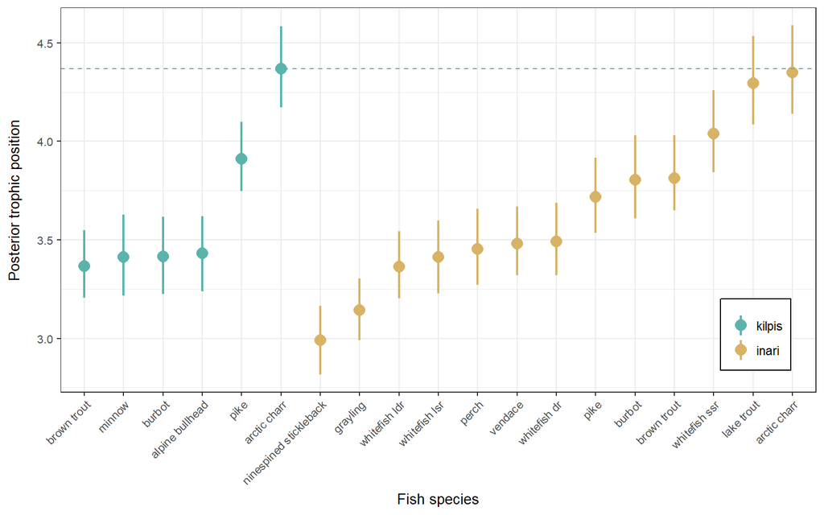

```r
plot_fishes + ggplot2::geom_hline(yintercept = max(MTP_modes),
                                  linetype = "44",
                                  colour = "#5ab4ac")
```

## References

1. Harrod, C., Mallela, J. & Kahilainen, K.K. 2010: Phenotype-environment correlations in a putative whitefish adaptive radiation. Journal of Animal Ecology 79: 1057-1068.
2. Hayden, B., Harrod, C. & Kahilainen, K.K. 2014: Dual-fuels: intra-annual variation in the relative importance of benthic and pelagic resources to maintenance, growth and reproduction in a generalist salmonid fish. Journal of Animal Ecology 83: 1501-1512.
3. Kahilainen, K.K., Østbye, K., Harrod, C., Shikano, T., Malinen, T. & Merilä, J. 2011: Species introduction promotes hybridization and introgression in Coregonus: is there sign of selection against hybrids? Molecular Ecology 20: 3838-3855.
4. Præbel, K., Knudsen, R., Siwertsson, A., Karhunen, M., Kahilainen, K.K., Ovaskainen, O., Østbye, K., Peruzzi, S. & Fevolden, S-E. & Amundsen P.-A 2013. Ecological speciation in postglacial European whitefish: rapid adaptive radiations into the littoral, pelagic and profundal lake habitats. Ecology and Evolution 3: 4970-4986.
5. Siwertsson, A., Knudsen, R., Kahilainen, K.K., Præbel, K., Primicerio, R. & Amundsen, P-A. 2010. Sympatric diversification as influenced by ecological opportunity and historical contingency in a young species lineage of whitefish. Evolutionary Ecology Research 12: 929-947.
6. Thomas, S.M., Harrod, C., Hayden, B., Malinen, T. & Kahilainen, K.K. 2017. Ecological speciation in a generalist consumer expands the trophic niche of a dominant predator. Scientific Reports. 7, 8765 doi: 10.1038/s41598-017-08263-9.